# Data 607: Nobel Prize Winners JSON

Author

Ellie Wilser

## Approach

I will start the assignment by connecting the Nobel Prize API and retrieving the data in JSON format. Also, I will find a data source with GDP per capita by year for all countries. I will have to do some filtering and basic data cleaning in this step.

After, I will begin preparing the data for analysis. I will have to join the GDP and Nobel Prize datasets, and create a calculated column for the laureates age when they win a nobel prize.

Finally, I will be sure to answer the questions in a way tabular and with visualizations.

## AI Usage

For this assignment, I want to focus on reading the Nobel Prize data from the API. I asked Claude to tell me the steps, then asking for the model to check my work. This week I focused my time on the Sentiment analysis, so the visualizations in this assignment where made by steering Claude. All the interpretation was done independently.

```r
library(dplyr)
library(httr2)
library(tidyverse)
```

## Gathering Data

### Nobel Prize Winners

```r
# Call the API to calculate offsets
first <- request("https://api.nobelprize.org/2.1/laureates") |>
  req_url_query(nobelPrizeYear = 1940,
                yearTo = 2025,
                format = 'json',
                limit = 1) |>
  req_perform() |>
  resp_body_json()

total <- first$meta$count

#Define Function
get_data <- function(offset){
  Sys.sleep(.5)
  request('https://api.nobelprize.org/2.1/laureates') |>
  req_url_query(
    nobelPrizeYear = 1940,
    yearTo = 2025,
    format = 'json',
    limit = 100,
    offset = offset
    ) |>
  req_retry(max_tries = 4, backoff = \(i) 60) |>
  req_perform() |>
  resp_body_json() |>
  pluck("laureates")
}
```

```r
#Call Function using Map
offsets <- seq(0,total-1,by=100)
laureates_raw <- map(offsets,get_data) |>
  list_flatten()
```

```r
# Tidying and creating calculated columns
laureates <- tibble(laureate = laureates_raw) |>
  hoist(laureate,
        id = "id",
        name = list("knownName", "en"),
        org_name = list("orgName", "en"),
        gender = "gender",
        birth_date = list("birth", "date"),
        birth_country = list("birth", "place", "countryNow", "en"),
        prizes = "nobelPrizes") |>
  select(-laureate) |>
  mutate(name = coalesce(name, org_name)) |>
  unnest_longer(prizes) |>
  hoist(prizes,
        award_year = "awardYear",
        category   = list("category", "en"),
        share      = "portion") |>
  select(-prizes, -org_name) |>
  mutate(award_year = as.integer(award_year),
         birth_year = as.integer(substr(birth_date, 1, 4)),
         age_at_award = award_year - birth_year) |>
  filter(between(award_year, 1940, 2025))
```

```r
glimpse(laureates)
```

```
Rows: 819
Columns: 10
$ id            <chr> "745", "102", "779", "259", "1004", "114", "982", "981",…
$ name          <chr> "A. Michael Spence", "Aage N. Bohr", "Aaron Ciechanover"…
$ gender        <chr> "male", "male", "male", "male", "male", "male", "male", …
$ birth_date    <chr> "1943-11-07", "1922-06-19", "1947-10-01", "1926-08-11", …
$ birth_country <chr> "USA", "Denmark", "Israel", "Lithuania", NA, "Pakistan",…
$ award_year    <int> 2001, 1975, 2004, 1982, 2021, 1979, 2019, 2019, 2009, 20…
$ category      <chr> "Economic Sciences", "Physics", "Chemistry", "Chemistry"…
$ share         <chr> "1/3", "1/3", "1/3", "1", "1", "1/3", "1/3", "1", "1/3",…
$ birth_year    <int> 1943, 1922, 1947, 1926, 1948, 1926, 1961, 1976, 1939, 19…
$ age_at_award  <int> 58, 53, 57, 56, 73, 53, 58, 43, 70, 42, 49, 53, 80, 71, …
```

### GDP per Capita

*Note: this section was created with the help of Claude (Anthropic’s AI assistant).*

The World Bank’s GDP series only goes back to 1960, so I’m using the [Maddison Project Database](https://www.rug.nl/ggdc/historicaldevelopment/maddison/), which has GDP per capita by country back to well before 1940 (in 2011 US dollars, adjusted for inflation and purchasing power). Our World in Data hosts it as a CSV, so it can be read straight from the web.

```r
gdp_raw <- read_csv(
  "https://ourworldindata.org/grapher/gdp-per-capita-maddison-project-database.csv?v=1&csvType=full&useColumnShortNames=true",
  # read_csv guesses column types from the first 1,000 rows; a mostly-empty
  # column gets guessed wrong, so look at every row before guessing
  guess_max = Inf
)
problems(gdp_raw)
```

| row | col | expected | actual | file |
| --- | --- | --- | --- | --- |

```r
names(gdp_raw)
```

```
[1] "entity"                      "code"
[3] "year"                        "gdp_per_capita"
[5] "gdp_per_capita__annotations"
```

```r
# the first three columns are country, code, year; the GDP value is the
# first numeric column after those (any other columns are text labels)
gdp_col <- gdp_raw |>
  select(-(1:3)) |>
  select(where(is.numeric)) |>
  names() |>
  first()

gdp <- gdp_raw |>
  rename(country = 1, code = 2, year = 3) |>
  select(country, code, year, gdp_per_capita = all_of(gdp_col)) |>
  # rows without a 3-letter code are regions (e.g. "Western Europe"), not countries
  filter(year >= 1940, !is.na(code), nchar(code) == 3) |>
  arrange(country, year) |>
  group_by(country) |>
  # year-over-year growth, for comparing current GDP vs. GDP growth (question 2)
  mutate(gdp_growth = (gdp_per_capita - lag(gdp_per_capita)) / lag(gdp_per_capita)) |>
  ungroup()

glimpse(gdp)
```

```
Rows: 12,093
Columns: 5
$ country        <chr> "Afghanistan", "Afghanistan", "Afghanistan", "Afghanist…
$ code           <chr> "AFG", "AFG", "AFG", "AFG", "AFG", "AFG", "AFG", "AFG",…
$ year           <dbl> 1950, 1951, 1952, 1953, 1954, 1955, 1956, 1957, 1958, 1…
$ gdp_per_capita <dbl> 1156, 1170, 1189, 1240, 1245, 1246, 1278, 1253, 1298, 1…
$ gdp_growth     <dbl> NA, 0.0121107266, 0.0162393162, 0.0428931876, 0.0040322…
```

## Analysis

### GDP per Capita vs. Number of Laureates

*Note: this section was created with the help of Claude (Anthropic’s AI assistant).*

First the countries were recoded to match the GDP data. This is needed to join the datasets.

```r
laureates <- laureates |>
  mutate(country = case_match(birth_country,
    "USA"                     ~ "United States",
    "the Netherlands"         ~ "Netherlands",
    "Czech Republic"          ~ "Czechia",
    c("Scotland", "Northern Ireland") ~ "United Kingdom",
    "Faroe Islands (Denmark)" ~ "Denmark",
    "Guadeloupe Island"       ~ "France",
    .default = birth_country
  ))
# any laureate countries still without a GDP match (should be empty or tiny)
laureates |>
  filter(!is.na(country)) |>
  distinct(country) |>
  anti_join(gdp |> distinct(country), by = "country")
```

| country |
| --- |
| East Timor |
| Democratic Republic of the Congo |
| Guadeloupe, France |

Next data was prepared to see the correlation between current GDP per Capita (2022) and number of laureates by countries.

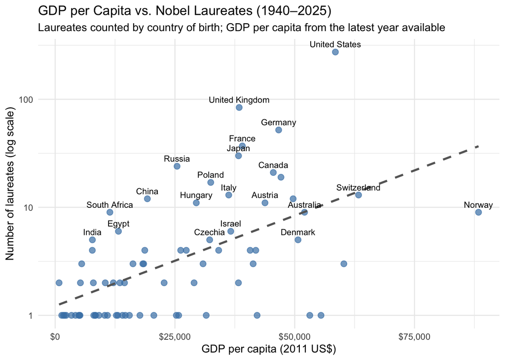

```r
winners_by_country <- laureates |>
  filter(!is.na(country)) |>
  distinct(id, country) |>
  count(country, name = "winners")

gdp_current <- gdp |>
  filter(!is.na(gdp_per_capita)) |>
  group_by(country) |>
  slice_max(year, n = 1) |>
  ungroup() |>
  select(country, gdp_year = year, gdp_per_capita)

gdp_winners <- winners_by_country |>
  inner_join(gdp_current, by = "country")

ggplot(gdp_winners, aes(x = gdp_per_capita, y = winners)) +
  geom_point(alpha = 0.7, size = 2.5, color = "steelblue") +
  geom_smooth(method = "lm", se = FALSE, color = "gray40", linetype = "dashed") +
  # label only countries with 5+ laureates so the chart stays readable
  geom_text(data = filter(gdp_winners, winners >= 5),
            aes(label = country), vjust = -0.8, size = 3, check_overlap = TRUE) +
  # log scale: the US has far more laureates than anyone else
  scale_y_log10() +
  scale_x_continuous(labels = scales::label_dollar()) +
  labs(title = "GDP per Capita vs. Nobel Laureates (1940–2025)",
       subtitle = "Laureates counted by country of birth; GDP per capita from the latest year available",
       x = "GDP per capita (2011 US$)",
       y = "Number of laureates (log scale)") +
  theme_minimal()
```

```r
cor(gdp_winners$gdp_per_capita, log10(gdp_winners$winners))
```

```
[1] 0.5661238
```

### GDP Growth vs. Number of Laureates

*Note: this section was created with the help of Claude (Anthropic’s AI assistant).*

GDP growth varies a lot from year to year, so the average growth in GDP from 1940 to current was used for analysis.

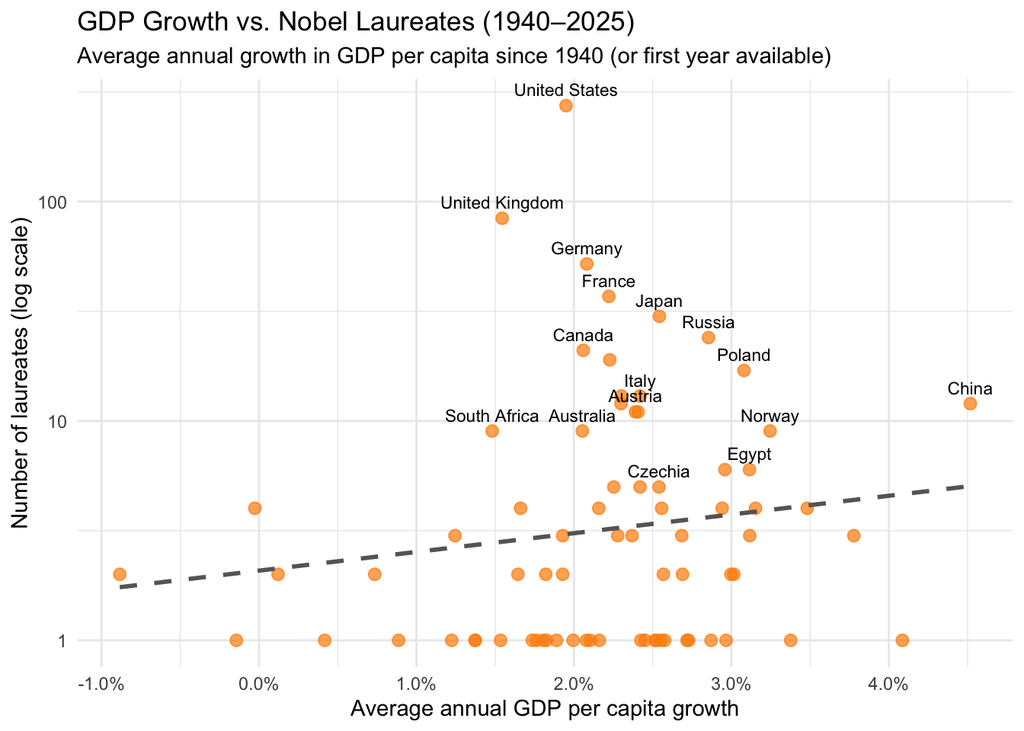

```r
gdp_growth_avg <- gdp |>
  filter(!is.na(gdp_per_capita)) |>
  group_by(country) |>
  summarise(start_year = min(year),
            end_year   = max(year),
            start_gdp  = gdp_per_capita[which.min(year)],
            end_gdp    = gdp_per_capita[which.max(year)]) |>
  # compound annual growth rate
  mutate(avg_growth = (end_gdp / start_gdp)^(1 / (end_year - start_year)) - 1) |>
  filter(end_year > start_year)

growth_winners <- winners_by_country |>
  inner_join(gdp_growth_avg, by = "country")

ggplot(growth_winners, aes(x = avg_growth, y = winners)) +
  geom_point(alpha = 0.7, size = 2.5, color = "darkorange") +
  geom_smooth(method = "lm", se = FALSE, color = "gray40", linetype = "dashed") +
  geom_text(data = filter(growth_winners, winners >= 5),
            aes(label = country), vjust = -0.8, size = 3, check_overlap = TRUE) +
  scale_y_log10() +
  scale_x_continuous(labels = scales::label_percent(accuracy = 0.1)) +
  labs(title = "GDP Growth vs. Nobel Laureates (1940–2025)",
       subtitle = "Average annual growth in GDP per capita since 1940 (or first year available)",
       x = "Average annual GDP per capita growth",
       y = "Number of laureates (log scale)") +
  theme_minimal()
```

Below is the comparison for the correlations.

```r
tibble(
  measure = c("Current GDP per capita", "Average GDP growth"),
  correlation_with_log_winners = c(
    cor(gdp_winners$gdp_per_capita, log10(gdp_winners$winners)),
    cor(growth_winners$avg_growth,  log10(growth_winners$winners))
  )
)
```

| measure | correlation_with_log_winners |
| --- | --- |
| Current GDP per capita | 0.5661238 |
| Average GDP growth | 0.1433319 |

### Laureate Age Over Time

*Note: this section was created with the help of Claude (Anthropic’s AI assistant).*

Age at award is the award year minus the birth year. Organizations have no birth date, so they’re left out. Each prize counts once, so a laureate who won twice is included at both ages.

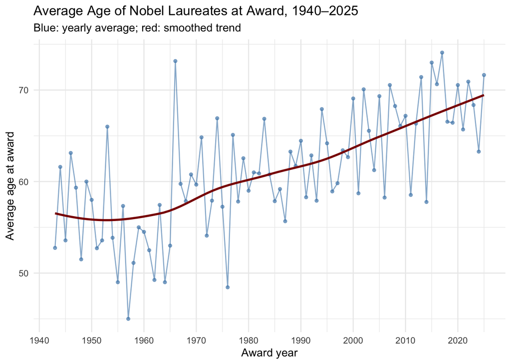

```r
age_by_year <- laureates |>
  filter(!is.na(age_at_award)) |>
  group_by(award_year) |>
  summarise(avg_age = mean(age_at_award),
            n_laureates = n())

ggplot(age_by_year, aes(x = award_year, y = avg_age)) +
  geom_line(color = "steelblue", alpha = 0.6) +
  geom_point(color = "steelblue", size = 1.2, alpha = 0.6) +
  # a smoothed trend makes the long-run direction easier to see
  geom_smooth(method = "loess", se = FALSE, color = "darkred", linewidth = 1) +
  scale_x_continuous(breaks = seq(1940, 2025, by = 10)) +
  labs(title = "Average Age of Nobel Laureates at Award, 1940–2025",
       subtitle = "Blue: yearly average; red: smoothed trend",
       x = "Award year",
       y = "Average age at award") +
  theme_minimal()
```

### Laureate Age by Category

*Note: this section was created with the help of Claude (Anthropic’s AI assistant).*

Most categories have only one to three laureates a year, so the yearly averages for a single category jump around too much to read as lines. Instead, each category gets a smoothed trend line through its laureates’ ages. Economics only starts in 1969, so its line is shorter.

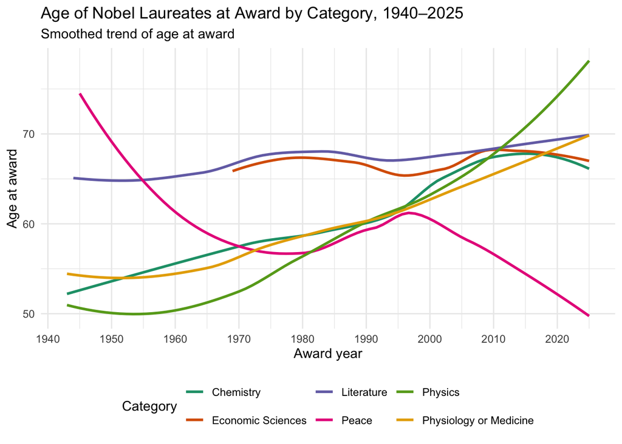

```r
laureates_age <- laureates |>
  filter(!is.na(age_at_award))

ggplot(laureates_age, aes(x = award_year, y = age_at_award, color = category)) +
  geom_smooth(method = "loess", se = FALSE, linewidth = 1) +
  scale_x_continuous(breaks = seq(1940, 2025, by = 10)) +
  scale_color_brewer(palette = "Dark2") +
  labs(title = "Age of Nobel Laureates at Award by Category, 1940–2025",
       subtitle = "Smoothed trend of age at award",
       x = "Award year",
       y = "Age at award",
       color = "Category") +
  theme_minimal() +
  theme(legend.position = "bottom")
```

```r
laureates_age |>
  group_by(category) |>
  summarise(laureates = n(),
            avg_age = round(mean(age_at_award), 1),
            median_age = median(age_at_award),
            youngest = min(age_at_award),
            oldest = max(age_at_award)) |>
  arrange(desc(avg_age))
```

| category | laureates | avg_age | median_age | youngest | oldest |
| --- | --- | --- | --- | --- | --- |
| Literature | 84 | 67.1 | 68.5 | 44 | 88 |
| Economic Sciences | 99 | 67.0 | 67.0 | 47 | 90 |
| Chemistry | 160 | 61.7 | 61.0 | 38 | 97 |
| Physics | 184 | 60.6 | 60.0 | 31 | 96 |
| Physiology or Medicine | 190 | 60.0 | 60.0 | 33 | 87 |
| Peace | 75 | 58.7 | 60.0 | 17 | 87 |

## Conclusion

Overall I enjoyed this assignment, and it gave me great experience working with different nested JSON files. To develop the code to unnest the JSON, I had to use the API documentation on the Nobel Peace Prize website. This was my first time working with an API documentation, and I’m excited to apply this knowledge in the future.

### GDP vs. Number of Laureates

There is a moderate positive linear relationship between current GDP and total numbers of laureates from 1940-2025, but when looking at growth the relationship is not as strong. This analysis includes the countries only have had 1 winner which shrinks the correlation coefficient. Further analyis could examine this by excluding countries with only 1 winner.

### Age of Laureates over Time

When looking at the age of laureates over time, it can be seen that the average age is increasing. There is many different factors which could influence this, but the average life expectancy has increased significantly from 1940 to 2026. Further analysis could normalize for this and see if there is still an increase in age.

When looking at age over time by Nobel prize category, the different categories have very different trends. The average age of Nobel peace prize winners has significantly decreased overtime while physics winner has increased. Most categories align with the increase we saw in the totals. I’d be curious to explore using different smoothing techniques in the graph.